# Vegetation indicator for mowing/grazing

[NO_FUBS_001] (open lowland)

Authors

Affiliation

Francesca Jaroszynska

Norwegian institute for nature research

Joachim Töpper

Norwegian institute for nature research

Published

September 14, 2026

Reviewed by

Aud Halbritter

> **Recommended citation**: Jaroszynska, F. and Töpper, J. 2026. Vegetation indicator for mowing/grazing (ID(s): NO_FUBS_001) v. 0.1.0. ecRxiv: https://github.com/NINAnor/ecRxiv/tree/main/indicators/NO_FUBS_001

**TipMetadata**

Table 1: Indicator metadata

| Variable | Value |
| --- | --- |
| Indicator ID | NO_FUBS_001 |
| Indicator Name | Vegetation indicator for mowing/grazing |
| verbatimName | Vegetasjonsindikator for beite eller slått |
| Country | Norway |
| Continent | Europe |
| Ecosystem Condition Typology Class | A1 - Physical State characteristics |
| Realm | Terrestrial (T) |
| Biome | T3 Shrublands and shrubby woodlands biome; T4 Savannas and grasslands biome; T7 Intensive land-use biome |
| Ecosystem | T4.5 Temperate grasslands; T3.4 Rocky pavements; T3.2 Seas dry temp shrublands; T7.5 Semi-natural old fields; åpen lavland |
| Year added | 2026 |
| Last update | 2026 |
| Version | 0.1.0 |
| Version comment |  |
| Normalised | TRUE |
| Spatial aggregation pathway | Scale/Truncate - Aggregate (zero-one inflated beta-regression) |
| Precision | 95% confidence intervals for the true value of the spatially aggregated indicator values derived from the beta-regression standard errors. |

**TipLog**

Presentation of mowing-grazing indicator for ANO, GRUK and ASO datasets

## 1. Summary

1. **Background and rationale**: Grazing and/or mowing is an important structuring and biomass reducing driver in both semi-natural and natural open lowland areas. This indicator represents plant community responses to grazing/mowing. Both inreased and decreased levels of grazing/mowing can be detrimental for the ecological condition of semi-natural and natural open lowland ecosystems. Thus, the indicator represents the lowest score of deviations from an optimal state either to higher or to lower levels of grazing/mowing.
2. **Methods**: The data originate from field sampled plant community data collected through three monitoring programmes: 1. the Norwegian nature monitoring program ANO (Tingstad et al. 2019), 2. GRUK, an open calcareous grasslands monitoring programme (Evju & Vang 2026), and finally 3. the ASO monitoring programme (Bär et al. 2025). We combine these with plant functional trait values from Tyler et al. (2021). Indicator values are based on calculating community-weighted means (Diekmann 2003, Töpper et al. 2018) or cumulative abundance (see Framstad et al. 2022) of functional trait values for plant community data. Deviations in such an indicator beyond a certain range of indicator values indicate a directional shift in the plant community. As reference communities we use ‘generalized species lists’ underlying the Norwegian categorization system for eco-diversity (Halvorsen et al. 2020, see Evju et al. 2023 for naturally open lowland ecosystems). For each major ecosystem type a separate set of indicators, related to the main drivers of change today, is computed. For open lowland ecosystems these are the vegetation indicators for nitrogen, light, moisture, pH, phosphorus, mowing/grazing, and soil disturbance. This file documents the 2-sided grazing/mowing indicator for open lowland.
3. **Interpretation**: An indicator value of 1 indicates no discernible difference in the functional plant composition due to impacts of altered levels of grazing/mowing. Values decreasing toward zero reflect a shift in species composition and community trait values away from the reference state, either as a response to increased or decreased grazing/mowing.
4. **Results and development needs**: The functional plant community indicator for grazing/mowing in Norway is 0.64 with 95% CI of 0.63-0.66, which means that the condition for this indicator is significantly higher than 0.6, the threshold for good ecological condition, though very close to the threshold. Deviations towards lower and higher grazing/mowing values are balanced, which means that deviations occur in both directions, indicating plant community composition shifts towards too little and too high grazing/mowing in all regions. The results are consistent for semi-natural types in both ANO and ASO.

To improve this indicator in the future, the perhaps most pressing issue it to regionalise the generalised species list, as currently they have a bias towards southern and eastern Norway. The indicator values also need validation against independent datasets.

Access to further years of data for the ASO monitoring scheme would strengthen its temporal and spatial representation, and thus the indicator’s robustness.

## 2. About the underlying data

We use three types of data for building functional plant community indicators for ecological condition:

- as observation data we use plant community data from the ANO monitoring scheme (cf. Tingstad et al. 2019), the ASO monitoring scheme (Bär et al. 2025), and the GRUK monitoring scheme (Evju and Vang 2026).
  - as reference data we use generalized species lists from the Norwegian categorization system for eco-diversity (NiN) (Halvorsen et al. 2020)
- Swedish functional plant indicator data from Tyler et al. (2021) and indicator values for plant strategies from Grime (1974)

For details see point 7 below.

### 2.1 Spatial and temporal resolution and extent

The ASO monitoring dataset is spatially representative of Norway, with each year’s sampling pool representative at a national and regional scale. ASO follows a 5-year monitoring cycle, with data spanning 2020-2024.

### 2.2 Sampling design

At every ANO site, the plant community is recorded (presence and percent cover of every vascular plant species) in the central 1 sqm plot of each of systematically arranged 18 monitoring points.

Within each GRUK site, one or several polygons matching the NiN mapping units T2-C-7 and T2-C-8 were delineated, and 5, 10, or 15 0.5 x 0.5 m permanent plots established, randomly selected from a 10 x 10 m grid within the polygons. All vascular plant species were recorded, including their percentage cover (visual estimate).

ASO is structured using a nested design consisting of ASO areas (10x10 km), ASO plots (500x500 m), and semi-natural meadows. Within each semi-natural meadow up to three transects were established, the length of each chosen to reflect the size of the meadow.

### 2.3 Original units

Abundance data for vascular plants in ANO is given as % cover within a 1 m2 sample quadrat, and within a 0.5 x 0.5 m sample quadrat for GRUK. This is transformed to relative abundance data per quadrat. Each ANO and GRUK quadrat is classified to its respective ecosystem type according to ‘Nature in Norway’ (NiN; https://artsdatabanken.no/NiN). Species diversity in ASO was recorded using cover and frequency classes (cf. modified measurement scale A7 for NiN2). Environmental indicator values from Tyler et al. (2021) are given on an ordinal scale from 1 (lowest affinity to the respective variable) to n (highest affinity to the respective variable), the number of levels (n) varying between environmental indicators.

### 2.4 Instructions for citing, using and accessing data

The ANO data are openly available at https://kartkatalog.miljodirektoratet.no/Dataset/Details/2054. See Section 2 for detail on the other datasets.

### 2.5 Additional comments about the dataset

The ANO, ASO and GRUK programs are run by the Norwegian Environment Agency. On their web sites you may also find additional summary data:

https://www.miljodirektoratet.no/ansvarsomrader/overvaking-arealplanlegging/miljoovervaking/overvakingsprogrammer/natur-pa-land/arealrepresentativ-naturovervakning-ano/

https://www.miljodirektoratet.no/ansvarsomrader/overvaking-arealplanlegging/miljoovervaking/overvakingsprogrammer/natur-pa-land/semi-naturlig-eng/

https://www.miljodirektoratet.no/ansvarsomrader/overvaking-arealplanlegging/miljoovervaking/overvakingsprogrammer/natur-pa-land/overvaking-av-apen-grunnlendt-kalkmark/

## 3. Indicator properties

### 3.1 Ecosystem Condition Typology Class (ECT)

The functional plant community indicator for mowing and grazing reflects the presence of physical structuring and biomass removal and thus represents the ECT class ‘A1 Physical characteristics’.

### 3.2 Ecosystem condition characteristic

The functional plant community indicator for mowing and grazing reflects the presence of physical structuring and biomass removal and thus represents the characteristic ‘Functionally important species and structures’.

### 3.3 Collinearities with other indicators

Different functional plant community indicators for different environmental variables (light, moisture, …) might show a certain degree of co-linearity with one another as they are derived from the very same plant community data. Functional plant community indicators can potentially exhibit co-linearities with other vegetation-oriented indicators, such as NDVI, though this depends greatly on which functional plant community indicator ends up as the leading one (i.e. the one with the lowest scaled score).

### 3.4 Impact factors

The plant community composition in open lowland ecosystems is subject to climatic changes in temperature and precipitation, land use changes (disturbance from human infrastructure, abandonment) as well as pollution (including fertilisation). The mowing and grazing indicator in semi-natural open lowland ecosystems responds primarily to changes in human land use.

### 3.5 Spatial aggregation

The variable is scaled, transformed (piece-wise linear) and truncated at the initial ANO-point level and the indicator estimate is a beta-regression-modelled mean of all ANO-, ASO, and GRUK-units..

## 4. Reference condition and levels

### 4.1 Reference condition

In Norway, the reference condition for natural ecosystems has been one of largely intact ecosystems without large-scale human modifications (Nybø and Evju 2017). For semi-natural ecosystems, human influence is allowed, and indeed a prerequisite, but then in the sense of appropriate, stable and traditional land-use practices. In terms of mowing and grazing, the reference condition is defined by a reference community.

### 4.2 Reference levels

Reference and limit values (scaling values) for this 2-sided functional plant community indicator are derived as the 0.025, 0.5, and 0.975 quantiles (lower limit values, reference value, upper limit value, respectively) from distributions of community weighted means of the respective plant indicators originating from bootstrapped generalized species lists. Bootstraps were set up with resampling of the original generalized species lists 1000 times. In every sample a random 1/3 of the original generalized species list was sampled (as ANO points on average contain roughly a third of the potential species richness in the generalized species lists -> local variation in species composition thus is large and needs to be reflected in the bootstraps), with the exception of dominant species (abundance value of 5 or higher in the original scale of the generalized species lists), which were retained in every sample. All reference distributions, and thus all scaling values are unique to NiN mapping units at a scale of 1:5000.

## 5. Uncertainties

### 5.1 General uncertainties

Uncertainties relate partly to sampling and observer variability (and possible observer bias) in the recording of the plant cover data. Presumably, there is also uncertainty related to the scoring of indicator values for species, and this will probably vary among species (cf. Tyler et al. 2021). These potential sources uncertainty can only be assumed and not quantified. Spatial variability as a source of uncertainty can be quantified. For every mean or median indicator value (after scaling) for every region (or any other delimited area of interest) we can calculate its corresponding standard error or confidence interval quantiles as a measure of spatial uncertainty for a geographical area. There is some uncertainty related to the ecosystem categorization at the field sites (see Ullerud et al. 2018 and Naas et al. 2023), but since ANO monitoring does not include spatial delineation of ecosystem polygons this problem is considered smaller than in spatial ecosystem mapping which these references mainly relate to. Similarly, this analysis is not crucially dependent on the exact delineation of the polygons, and the plots and transects in GRUK and ASO placed and assessed within the polygons hold little uncertainty of not being the target types of the two monitoring programmes. Other uncertainties connected to the indicator arise from community weighted means calculated from plant communities of different species richness in the observation data; since no uncertainty measure for these community-weighted means is calculated and propagated, the actual uncertainty of functional community signals for the single community observations is unknown.

There is some uncertainty about the appropriateness of using (Halvorsen et al. 2020) as a reference dataset and a reference plant community for different nature types, and especially for different geographical and environenmetal regions of Norway. The dataset has a known bias towards south and eastern Norway, and may not reflect the natural plant communities equally well in the western and northern parts.

### 5.2 Reported uncertainties

For this indicator, we report 95% confidence intervals as inferential uncertainty based on a statistical model (zero-one inflated beta-regression).

## 6. References

Artsdatabanken (2023, 11. august). Fremmede arter i Norge - med økologisk risiko 2023. http://www.artsdatabanken.no/lister/fremmedartslista/2023.

Bär, A., Solbu, E., Vassvik, L., Velle, L.G. & L. Johansen 2025. Arealrepresentativ Overvåking av Semi-naturlig eng (ASO). Resultater fra 1. omløp og anbefalinger for veien. (NIBIO RAPPORT, 11/149). Norsk institutt for bioøkonomi.

Bär, Johansen, Vesterbukt, Svalheim, Daugstad, Hinderaker, Thorvaldsen, Albertsen, Carlsen, Grenne, Maurset, Øien, Heimstad, Lyngstad, Hasvik, Ombler, Wehn, Moen, Blütecher, Leh, Davidsen, Paulsen, Vassvik, Sundsdal, Velle, Solstad, Bele, Solbu, Winther, Henriksen, Nesheim-Hauge, Høydal (2025). Overvåking av semi-naturlig eng (ASO). Version 1.8. Norwegian Institute of Bioeconomy Research. Sampling event dataset https://doi.org/10.15468/gq6wa5 accessed via GBIF.org on 2026-09-11.

Diekmann, M. 2003. Species indicator values as an important tool in applied plant ecology - a review. Basic and Applied Ecology 4: 493-506, doi:10.1078/1439-1791-00185

Evju, M., Olsen, S.L., Prestø, T., Vange, V., Bratli, H. & Töpper, J. 2023. Ecological condition of naturally open areas below the forest line. Background, proposed indicators, and knowledge needs. NINA Report 2341. Norwegian Institute for Nature Research.

Evju M, & Vang R 2026. Overvåking av åpen grunnlendt kalkmark i Oslofjordområdet. Version 1.20. Norwegian Institute for Nature Research. Occurrence dataset. https://ipt.nina.no/resource?r=gruk_2020&v=1.20

Framstad, E., Kolstad, A. L., Nybø, S., Töpper, J. & Vandvik, V. 2022. The condition of forest and mountain ecosystems in Norway. Assessment by the IBECA method. NINA Report 2100. Norwegian Institute for Nature Research.

Halvorsen, R., Skarpaas, O., Bryn, A., Bratli, H., Erikstad, L., Simensen, T., & Lieungh, E. (2020). Towards a systematics of ecodiversity: The EcoSyst framework. Global Ecology and Biogeography, 29(11), 1887-1906. doi:10.1111/geb.13164

Jakobsson, S., Töpper, J.P., Evju, M., Framstad, E., Lyngstad, A., Pedersen, B., Sickel, H., Sverdrup-Thygeson, A., Vandvik. V., Velle, L.G., Aarrestad, P.A. & Nybø, S. 2020. Setting reference levels and limits for good ecological condition in terrestrial ecosystems. Insights from a case study based on the IBECA approach. Ecological Indicators 116: 106492.

Jakobsson, S., Evju, M., Framstad, E., Imbert, A., Lyngstad, A., Sickel, H., Sverdrup-Thygeson, A., Töpper, J., Vandvik, V., Velle, L.G., Aarrestad, P.A. & Nybø, S. 2021. An index-based assessment of ecological condition and its links to international frameworks. Ecological Indicators 124: 107252.

Naas, A.E., Halvorsen, R., Horvath, P., Wollan, A.K., Bratli, H., Brynildsrud, K. et al. (2023) What explains inconsistencies in field-based ecosystem mapping? Applied Vegetation Science, 26, e12715. Available from: https://doi.org/10.1111/avsc.12715

Nybø, S. & Evju, M. (red.) 2017. Fagsystem for fastsetting av god økologisk tilstand. Forslag fra et ekspertråd, https://regjeringen.no/no/dokument/rapportar-og-planar/id438817/.

Tingstad, L., Evju, M., Sickel, H., & Töpper, J. 2019. Utvikling av nasjonal arealrepresentativ naturovervåking (ANO). Forslag til gjennomføring, protokoller og kostnadsvurderinger med utgangspunkt i erfaringer fra uttesting i Trøndelag. NINA Rapport 1642.

Töpper, J., Velle, L.G. & Vandvik, V. 2018. Developing a method for assessment of ecological state based on indicator values after Ellenberg and Grime (revised edition). NINA Report 1529b. Norwegian Institute for Nature Research.

Tyler, T., Herbertsson, L., Olofsson, J., & Olsson, P. A. 2021. Ecological indicator and traits values for Swedish vascular plants. Ecological In-dicators, 120. doi:10.1016/j.ecolind.2020.106923

Ullerud HA, Bryn A, Halvorsen R, Hemsing LØ. Consistency in land-cover mapping: Influence of field workers, spatial scale and classification system. Appl Veg Sci. 2018; 21: 278–288. https://doi.org/10.1111/avsc.12368

## 7. Import and prepare datasets

### 7.1 Dataset A

Download and load the WFO plant list backbone from Zenodo:

```r
source(paste0(here(), "/R/functions.R"))
source(paste0(here(), "/R/species_dictionary.R"))
```

### 7.2. Dataset B

Import plant indicator values from Tyler et al. (2021):

```r
tyler_indicators <- read_rds(paste0(here(), "/data/cache/tyler_indicators.RDS"))
```

The Swedish plant indicator values dataset published by Tyler et al. (2021) contains a large collection of plant indicators based on the Swedish flora, which is well representative of the Norwegian flora as well. From this set, we use indicator data for mowing and grazing as this is thought to be subject to potential change due to ongoing pressures in the respective ecosystems (see details above under 3.4 ‘Impact factors’).

### 7.3. Dataset C

Import Reference data from NiN:

```r
nin_sp_ind <- read_rds(paste0(here::here(), "/data/cache/nin_sp_ind.RDS"))
```

The generalized species lists underlying the ecosystem categorization in NiN (Halvorsen et al. 2020) represent expert-compiled species lists based on empirical evidence from the literature and expert knowledge of the systems and their species. In these lists, every species is assigned an abundance value on a 6-step scale, with each step representing a range for the ‘expected combination of frequency and cover’ of occurrence:

1 = < 1/32, 2 = 1/32 - 1/8, 3 = 1/8 - 3/8, 4 = 3/8 - 4/5, 5 = 3/8 - 4/5 + dominance, 6 = > 4/5

For the purpose of this project, these steps are simplified to maximum expected combination of frequency and cover, whereby steps 4 & 5 are assigned 0.6 and 0.8, respectively, in order to distinguish between them.

### 7.4 Dataset D

Import ANO testing data: First, download from Miljødirektoratet (downloaded spring 2026). Then upload from local storage. The geodatabase contains several layers; ‘ANO_SurveyPoint’ contains site and point data including alien plant species cover.

### 7.5 Dataset E

Import GRUK data

### 7.6 Dataset F

Import ASO data

## 8. Spatial units

The spatial units for functional plant community indicators are governed by the ANO data, which consist of 1000 randomly chosen sites in Norway. Each site is a 500 x 500 m grid cell with 18 monitoring points of 250sqm and a central 1 x 1 m vegetation plot. The basic unit for which observational community data exist, and for which every functional plant community indicator is computed, is this central 1 x 1 m vegetation plot. Aggregation of these basic spatial units to higher ones - like sites, municipalities, counties, regions, or the national level - should be done with appropriate consideration of the spatial structure of the data, i.e. imbalances and clustering (highly unequal number of points of an ecosystem type between sites).

## 9. Analyses

#### Data handling

- Checking for errors
- Checking species nomenclature in the different species lists to make species and indicator data possible to merge
- Merging indicator data with monitoring data and indicator data with reference data (not shown here, but documented in the code)

```r
source(paste0(here::here(), "/R/spatial_data.R"))
```

```r
# 2.0 Plant indicator data
source(paste0(here::here(), "/R/cleaning_tyler.R"))

# 2.1 GRUK data
source(paste0(here::here(), "/R/cleaning_gruk.R"))

# 2.2 ASO
source(paste0(here::here(), "/R/cleaning_aso.R"))

#### 2.3 ANO monitoring data
source(paste0(here::here(), "/R/cleaning_ano.R"))

# 2.4 NiN species data
source(paste0(here::here(), "/R/cleaning_nin.R"))


rm(wfo_backbone)
```

This leaves us with the monitoring data including plant indicators (ano_all, gruk_all, aso_all) and the reference data including plant indicators (nin_sp_ind):

Species occurrence data set for ANO with attached plant trait data.

| species | art_dekning | parentglobalid | Moisture | Nitrogen | Soil_disturbance_2 | Grazing_mowing | Phosphorus | Soil_reaction_pH | Light | Soil_disturbance_1 | ano_flate_id | ano_punkt_id | ssb_id | aar | hovedtype_rute | kartleggingsenhet_1m2 |
| --- | --- | --- | --- | --- | --- | --- | --- | --- | --- | --- | --- | --- | --- | --- | --- | --- |
| Gymnocarpium dryopteris | 1.0 | {002B7973-3829-4E83-8940-0807B6053201} | 4 | 6 | 1 | 1 | 4 | 4 | 2 | 1 | ANO0020 | ANO0020_46 | 19875006550500 | 2024 | T31 | T31-C-2 kalkfat |
| Gymnocarpium dryopteris | 4.0 | {5DCC0413-45F3-4142-9EA7-26F4833F9FEE} | 4 | 6 | 1 | 1 | 4 | 4 | 2 | 1 | ANO0108 | ANO0108_26 | 22400006818000 | 2024 | T31 | T31-C-13 interm |
| Gymnocarpium dryopteris | 0.1 | {3D6F8F30-B170-4913-B746-2DFCCA53ADF0} | 4 | 6 | 1 | 1 | 4 | 4 | 2 | 1 | ANO0108 | ANO0108_64 | 22400006818000 | 2024 | T31 | T31-C-11 sterkt |
| Gymnocarpium dryopteris | 1.0 | {D92859FF-9C0E-4790-B212-501DFEBD4F28} | 4 | 6 | 1 | 1 | 4 | 4 | 2 | 1 | ANO0108 | ANO0108_62 | 22400006818000 | 2024 | T31 | T31-C-2 kalkfat |
| Gymnocarpium dryopteris | 6.0 | {CDE1B72B-5D58-480D-9C39-67DF7840F357} | 4 | 6 | 1 | 1 | 4 | 4 | 2 | 1 | ANO0108 | ANO0108_35 | 22400006818000 | 2024 | T31 | T31-C-2 kalkfat |
| Gymnocarpium dryopteris | 5.0 | {63410CC2-2570-4D85-923E-651A8B71A25B} | 4 | 6 | 1 | 1 | 4 | 4 | 2 | 1 | ANO0108 | ANO0108_15 | 22400006818000 | 2024 | T31 | T31-C-1 kalkfat |

Reference data set for semi-natural ecosystems

| Nature_Type | Sub_Type | nin_id | nin_code | species | species_group | cover | Moisture | Nitrogen | Soil_disturbance_2 | Grazing_mowing | Phosphorus | Soil_reaction_pH | Light | Soil_disturbance_1 |
| --- | --- | --- | --- | --- | --- | --- | --- | --- | --- | --- | --- | --- | --- | --- |
| Coastal_Heath | T1 | CH08 | T34-C4b | Achillea millefolium | a1c | 1 | 2 | 5 | 2 | 5 | 5 | 5 | 6 | 2 |
| Coastal_Heath | T1 | CH09 | T34-C4c | Achillea millefolium | a1c | 1 | 2 | 5 | 2 | 5 | 5 | 5 | 6 | 2 |
| Coastal_Heath | T1 | CH12 | T34-C5b | Achillea millefolium | a1c | 1 | 2 | 5 | 2 | 5 | 5 | 5 | 6 | 2 |
| Coastal_Heath | T1 | CH15 | T34-C6b | Achillea millefolium | a1c | 1 | 2 | 5 | 2 | 5 | 5 | 5 | 6 | 2 |
| Semi_Natural | SemiNatMeadow | SN08 | T32-C1C2 | Achillea millefolium | a1c | 1 | 2 | 5 | 2 | 5 | 5 | 5 | 6 | 2 |
| Semi_Natural | SemiNatMeadow | SN09 | T32-C3C4 | Achillea millefolium | a1c | 4 | 2 | 5 | 2 | 5 | 5 | 5 | 6 | 2 |

For each ecosystem type with a NiN species list, we can calculate a community weighted mean (CWM) for the relevant functional plant indicators. In order to get distributions of these metrics rather than one single value (for comparison with the empirical testing data) the NiN lists can be bootstrapped.

##### Bootstrap functions for frequency abundance and cumulative density

- function to calculate community weighted means (indBoot.freq() ) or cumulative density (indBoot.HeatOverhang() ) of selected indicator values (ind)
- for species lists (sp) with given abundances in percent (or on a scale from 0 to 1) in one or more ‘sites’ (abun)
- with a given number of iterations (iter),
- with species given a certain minimum abundance occurring in all bootstraps (obl), and
- with a given re-sampling ratio of the original species list (rat)
- in every bootstrap iteration the abundance of the sampled species can be randomly changed by a limited amount if wished by introducing a re-sampling of abundance values from adjacent abundance steps with a certain probability (var.abun)

```r
# see the indBoot.freq function in the functions script for details.
indBoot.freq
```

##### Running the bootstraps:

- we choose 1000 iterations
- species with abundance 0.8 or more (dominant species) must be included in each sample
- each sample re-samples 1/3 of the number of species
- the abundance of the re-sampled species may vary (see bootstrap function for details)

```r
source(paste0(here::here(), "/R/bootstrapping.R"))
```

```r
head(lowland_ref_cov[[1]]) |>
  kable("html", caption = "Table showing the first 6 rows of the bootstrapped data set.") |> kable_styling("striped") |> scroll_box(width = "100%")
```

Table showing the first 6 rows of the bootstrapped data set.

| T34-C4b | T34-C4c | T34-C5b | T34-C6b | T32-C1C2 | T32-C3C4 | T32-C5C20a | T32-C7C8 | T32-C5C20b | T32-C9a | T32-C9b | T32-C15 | T32-C21C6a | T32-C21C6b | T32-C10a | T32-C10b | T32-C16 | T41a | T41b | T45-C1C2 | T34-C1 | T34-C2a | T34-C2b | T34-C2c | T34-C3 | V10-C1C2 | V10-C3 | T45-C3 | T12-C-2 | T15 | … |
| --- | --- | --- | --- | --- | --- | --- | --- | --- | --- | --- | --- | --- | --- | --- | --- | --- | --- | --- | --- | --- | --- | --- | --- | --- | --- | --- | --- | --- | --- | --- |
| 4.736111 | 5.264550 | 4.710366 | 4.333333 | 5.517711 | 4.632300 | 5.001900 | 5.082353 | 4.339717 | 5.186299 | 5.770454 | 4.745223 | 5.147106 | 4.637097 | 4.802828 | 4.954677 | 5.477537 | 5.084785 | 5.010811 | 4.166667 | 5.673077 | 4.707317 | 5.731343 | 5.500000 | 4.974359 | 4.625000 | 4.702290 | 3.947464 | 5.875661 | 5.658910 | … |
| 4.956522 | 5.139949 | 5.121951 | 4.937695 | 5.590433 | 5.200428 | 4.768687 | 4.451111 | 4.627927 | 5.020408 | 5.694565 | 4.730471 | 5.536421 | 4.702302 | 4.788721 | 4.579041 | 4.903670 | 4.882038 | 4.736374 | 4.520000 | 6.444444 | 4.547945 | 5.169231 | 5.253731 | 6.800000 | 4.767660 | 4.664384 | 4.783557 | 5.771093 | 5.009281 | … |
| 4.989691 | 5.152672 | 5.303514 | 4.625000 | 5.639416 | 5.748638 | 5.349126 | 4.609920 | 5.279898 | 5.041667 | 5.570768 | 5.408040 | 5.065159 | 4.888300 | 4.874259 | 5.311532 | 5.282662 | 5.098179 | 5.008866 | 4.791296 | 5.533808 | 4.986842 | 5.745763 | 5.049180 | 6.204546 | 5.094688 | 4.611555 | 4.875899 | 5.807107 | 5.200980 | … |
| 5.333333 | 5.163043 | 5.399361 | 3.916667 | 5.589630 | 5.111328 | 4.643702 | 4.782534 | 5.028097 | 4.714632 | 4.853580 | 5.396643 | 4.708700 | 4.731816 | 4.675214 | 4.386667 | 4.831539 | 5.409768 | 4.861842 | 4.431520 | 6.289474 | 5.328571 | 5.880597 | 5.694444 | 5.393443 | 4.479806 | 4.612849 | 3.656951 | 5.684932 | 6.034164 | … |
| 4.635135 | 4.771689 | 4.866864 | 4.666667 | 5.636678 | 4.651182 | 4.754242 | 4.710067 | 5.005062 | 5.578358 | 5.184235 | 4.916950 | 5.454418 | 4.968937 | 4.755132 | 5.210012 | 4.807478 | 5.286385 | 5.224228 | 4.737198 | 5.373832 | 4.988889 | 5.442857 | 5.378788 | 5.081967 | 4.548951 | 4.909427 | 3.628114 | 5.953294 | 5.061639 | … |
| 5.410256 | 5.155807 | 4.878049 | 4.494220 | 6.264384 | 5.143325 | 5.270357 | 4.436135 | 4.519223 | 4.869658 | 5.015009 | 5.378241 | 5.395925 | 4.958904 | 4.977226 | 4.855275 | 4.699634 | 5.450645 | 5.092391 | 4.883165 | 5.313653 | 4.957143 | 5.731343 | 5.328358 | 4.360000 | 4.157293 | 4.864764 | 3.841046 | 5.613421 | 5.218341 | … |

This results in an R-list for open lowland and semi-natural ecosystem types, with a data frame for every selected plant indicator and each data frame with as many columns as there are NiN species lists and as many rows as there were iterations in the bootstrap.

Next, we need to derive scaling values from these bootstrap-lists (the columns) for every mapping unit in NiN. Here, we define things in the following way:

- Median = reference values
- 0.025 and 0.975 quantiles = lower and upper limit values
- min and max of the respective indicators scale = min/max values

```r
source(paste0(here::here(), "/R/scaling.R"))

# every NiN-type is represented by one 'generalisert artsliste'
# some NiN-types are represented by two such species lists
# in some cases two NiN-types are represented by the same species list
```

We then merge the cleaned and scaled datasets for the test data.

```r
source(paste0(here::here(), "/R/merge_datasets.R"))
```

Below, we load in the merged sepcies and environmental data, alongside the reference data.

```r
regnor <- read_rds(paste0(here::here(), "/data/cache/regnor.RDS"))
combined_lowlands <- read_rds(paste0(here::here(), "/data/cache/combined_lowlands.RDS"))
combined_species <- read_rds(paste0(here::here(), "/data/cache/combined_species.RDS"))
lowland_ref_cov_val <- read_rds(paste0(here::here(), "/data/cache/lowland_ref_cov_val.RDS"))
```

```r
lowland_ref_cov_val |>
  kable("html", caption = "Reference values (Rv and threshold values (Gv) for each indicator and nature type combination") |> kable_styling("striped") |> scroll_box(width = "100%", height = "300px")
```

Reference values (Rv and threshold values (Gv) for each indicator and nature type combination

| grunn | county | region | Ind | Rv | Gv | maxmin |
| --- | --- | --- | --- | --- | --- | --- |
| T11-C-1 | all | all | Moisture1 | 4.660000 | 3.636364 | 1 |
| T11-C-1 | all | all | Moisture2 | 4.660000 | 5.802198 | 12 |
| T11-C-2 | all | all | Moisture1 | 5.357542 | 4.838509 | 1 |
| T11-C-2 | all | all | Moisture2 | 5.357542 | 5.876279 | 12 |
| T12-C-1 | all | all | Moisture1 | 4.494859 | 4.077540 | 1 |
| T12-C-1 | all | all | Moisture2 | 4.494859 | 4.929777 | 12 |
| T12-C-2 | all | all | Moisture1 | 5.739914 | 5.241578 | 1 |
| T12-C-2 | all | all | Moisture2 | 5.739914 | 6.246650 | 12 |
| T13-C-4 | all | all | Moisture1 | 4.000000 | 2.333333 | 1 |
| T13-C-4 | all | all | Moisture2 | 4.000000 | 6.000000 | 12 |
| T13-C-5 | all | all | Moisture1 | 4.750000 | 3.000000 | 1 |
| T13-C-5 | all | all | Moisture2 | 4.750000 | 6.000000 | 12 |
| T13-C-6 | all | all | Moisture1 | 4.920000 | 3.719857 | 1 |
| T13-C-6 | all | all | Moisture2 | 4.920000 | 5.785714 | 12 |
| T13-C-7 | all | all | Moisture1 | 5.166667 | 3.333333 | 1 |
| T13-C-7 | all | all | Moisture2 | 5.166667 | 6.777778 | 12 |
| T13-C-8 | all | all | Moisture1 | 5.000000 | 3.250000 | 1 |
| T13-C-8 | all | all | Moisture2 | 5.000000 | 7.000000 | 12 |
| T13-C-9 | all | all | Moisture1 | 5.301331 | 4.060913 | 1 |
| T13-C-9 | all | all | Moisture2 | 5.301331 | 6.449422 | 12 |
| T15 | all | all | Moisture1 | 5.280801 | 4.833254 | 1 |
| T15 | all | all | Moisture2 | 5.280801 | 5.785997 | 12 |
| T16-C-1 | all | all | Moisture1 | 5.666667 | 4.555556 | 1 |
| T16-C-1 | all | all | Moisture2 | 5.666667 | 6.895833 | 12 |
| T16-C-2 | all | all | Moisture1 | 5.619225 | 4.480000 | 1 |
| T16-C-2 | all | all | Moisture2 | 5.619225 | 6.826697 | 12 |
| T16-C-3 | all | all | Moisture1 | 5.206370 | 4.318236 | 1 |
| T16-C-3 | all | all | Moisture2 | 5.206370 | 6.146565 | 12 |
| T16-C-4 | all | all | Moisture1 | 5.160000 | 4.243927 | 1 |
| T16-C-4 | all | all | Moisture2 | 5.160000 | 6.143724 | 12 |

[output cut: 1138 more lines]

Once test data and the scaling values from the reference data are in place, we can calculate CWMs of the selected indicator for the ANO community data and scale them against the scaling values from the reference distribution. Note that we scale each ANO plot’s CWM against either the lower threshold value and the min value OR the upper threshold value and the max value based on whether the CWM is smaller or higher than the reference value. Since the scaled values for both sides range between 0 and 1, we generate separate lower and upper indicators for each plant functional indicator type. An ANO plot can only have a scaled value in either the lower or the upper indicator (the other one will be ‘NA’), except for the unlikely event that the CWM exactly matches the reference value, in which case both lower and upper indicator will receive a scaled indicator value of 1.

For scaling ANO-data against the reference we use the normalisation function from package ecTools.

```r
#### 1. calculating scaled and non-truncated values for the indicators based on the datasets ####
ref_grunn <- unique(sub("\\-.*", "", as.character(lowland_ref_cov_val$grunn)))
combined_species <- combined_species |> filter(!is.na(Grazing_mowing))
lowland_ref_cov_val <- lowland_ref_cov_val |> filter(Ind %in% c("Grazing_mowing1", "Grazing_mowing2"))


for (i in seq_len(nrow(combined_lowlands))) {
  tryCatch({

    ds       <- combined_lowlands$dataset[i]
    hoved_i  <- as.character(combined_lowlands$hovedtype_rute[i])
    global_i <- as.character(combined_lowlands$globalid_chr[i])
    nin_i    <- as.character(combined_lowlands$kartleggingsenhet[i])

    # 1) hovedtype must exist in ref
    cond_hoved <- !is.na(hoved_i) && hoved_i %in% ref_grunn
    if (!isTRUE(cond_hoved)) next

    # 2) species data for this row and dataset
    dat <- combined_species |>
      dplyr::filter(
        dataset == ds,
        parentglobalid == global_i
      ) |>
      dplyr::select(art_dekning, Grazing_mowing)

    if (nrow(dat) == 0) next

    combined_lowlands$richness[i] <- nrow(dat)
    dat <- dat[!is.na(dat$Grazing_mowing), ]
    if (nrow(dat) == 0) next

    # 3) CWM Grazing mowing
    val <- sum(dat$art_dekning * dat$Grazing_mowing, na.rm = TRUE) /
      sum(dat$art_dekning, na.rm = TRUE)

    ## Grazing_mowing1
    idx1 <- lowland_ref_cov_val$Ind == "Grazing_mowing1" &
      lowland_ref_cov_val$grunn == nin_i
    idx1[is.na(idx1)] <- FALSE

    if (sum(idx1) == 1) {
      ref1    <- as.numeric(lowland_ref_cov_val$Rv[idx1][[1]])
      lim1    <- as.numeric(lowland_ref_cov_val$Gv[idx1][[1]])
      maxmin1 <- as.numeric(lowland_ref_cov_val$maxmin[idx1][[1]])

      if (!any(is.na(c(ref1, lim1, maxmin1)))) {
        combined_lowlands$Grazing_mowing1[i] <- ec_normalise(
          variable = val,
          x0   = maxmin1,
          x60  = lim1,
          x100 = ref1,
          fun  = "linear"
        )
      }
    }

    ## Grazing_mowing2
    idx2 <- lowland_ref_cov_val$Ind == "Grazing_mowing2" &
      lowland_ref_cov_val$grunn == nin_i
    idx2[is.na(idx2)] <- FALSE

    if (sum(idx2) == 1) {
      ref2    <- as.numeric(lowland_ref_cov_val$Rv[idx2][[1]])
      lim2    <- as.numeric(lowland_ref_cov_val$Gv[idx2][[1]])
      maxmin2 <- as.numeric(lowland_ref_cov_val$maxmin[idx2][[1]])

      if (!any(is.na(c(ref2, lim2, maxmin2)))) {
        combined_lowlands$Grazing_mowing2[i] <- ec_normalise(
          variable = val,
          x0   = maxmin2,
          x60  = lim2,
          x100 = ref2,
          fun  = "linear"
        )
      }
    }

  }, error = function(e) {
    cat("ERROR at row", i, ":", conditionMessage(e), "\n")
  })
}


combined_lowlands <- combined_lowlands |>
  filter(hovedtype_rute %in% c("T32", "V10", "T41", "T34", "V45")) |>
  dplyr::mutate(
    Grazing_mowing  = Grazing_mowing1 * Grazing_mowing2,
    Grazing_mowing1 = if_else(Grazing_mowing1 == 1, NA_real_, Grazing_mowing1),
    Grazing_mowing2 = if_else(Grazing_mowing2 == 1, NA_real_, Grazing_mowing2)
  )
```

```r
head(combined_lowlands) |>
  kable("html", caption = "Plots for ecosystems with scaled indicator values in the far-right columns.") |>
  kable_styling("striped") |> scroll_box(width = "100%")
```

Plots for ecosystems with scaled indicator values in the far-right columns.

| dataset | globalid | nest_1 | ano_punkt_id | ssb_id | aar | hovedoekosystem_250m2 | hovedoekosystem_rute | hovedtype_rute | hovedtype_250m2 | hovedtype_1m2 | kartleggingsenhet | kartleggingsenhet_250m2 | X | Y | globalid_chr | scale | nin_kartleggingsenheter | hovedokosystem | location_id | id | region | GID_0 | NAME_0 | richness | Grazing_mowing1 | Grazing_mowing2 | Grazing_mowing |
| --- | --- | --- | --- | --- | --- | --- | --- | --- | --- | --- | --- | --- | --- | --- | --- | --- | --- | --- | --- | --- | --- | --- | --- | --- | --- | --- | --- |
| ANO | {6A82CBAF-BD0F-40EE-9ECD-679D064DA5D2} | ANO0007 | ANO0007_42 | 21145006491000 | 2019 | vaatmark | Seminat | V10 | NA | Semi-naturlig våteng | V10-C-1 | NA | 114630 | 6491290 | {6A82CBAF-BD0F-40EE-9ECD-679D064DA5D2} | 1m2 | NA | NA | NA | 5 | Southern_Norway | NOR | Norway | 2 | NA | 0.5657319 | 0.5657319 |
| ANO | {F895016D-46E3-4DC4-81AC-22060D841C05} | ANO0016 | ANO0016_35 | 20485006950500 | 2019 | semi_naturlig_mark | Seminat | T34 | NA | Kystlynghei | T34-C-2 | NA | 48870 | 6950710 | {F895016D-46E3-4DC4-81AC-22060D841C05} | 1m2 | NA | NA | NA | 2 | Central_Norway | NOR | Norway | 10 | 0.7594009 | NA | 0.7594009 |
| ANO | {B3A03D40-EA4E-4E4F-8FA0-A5FD96D44F37} | ANO0016 | ANO0016_11 | 20485006950500 | 2019 | semi_naturlig_mark | Seminat | T34 | NA | Kystlynghei | T34-C-2 | NA | 48550 | 6950550 | {B3A03D40-EA4E-4E4F-8FA0-A5FD96D44F37} | 1m2 | NA | NA | NA | 2 | Central_Norway | NOR | Norway | 8 | 0.5766739 | NA | 0.5766739 |
| ANO | {00C75C7D-70A0-40B7-A43D-1FB83A4108EE} | ANO0016 | ANO0016_15 | 20485006950500 | 2019 | semi_naturlig_mark | Seminat | T34 | NA | Kystlynghei | T34-C-2 | NA | 48870 | 6950550 | {00C75C7D-70A0-40B7-A43D-1FB83A4108EE} | 1m2 | NA | NA | NA | 2 | Central_Norway | NOR | Norway | 6 | 0.5817034 | NA | 0.5817034 |
| ANO | {8213D53A-A0EB-47BE-BCE2-0A6D267F1F59} | ANO0016 | ANO0016_24 | 20485006950500 | 2019 | semi_naturlig_mark | Seminat | T34 | NA | Kystlynghei | T34-C-2 | NA | 48790 | 6950630 | {8213D53A-A0EB-47BE-BCE2-0A6D267F1F59} | 1m2 | NA | NA | NA | 2 | Central_Norway | NOR | Norway | 8 | 0.5849832 | NA | 0.5849832 |
| ANO | {85586A80-718C-464D-BD41-0C6681E36468} | ANO0019 | ANO0019_13 | 23275006736000 | 2019 | semi_naturlig_mark | Seminat | T32 | NA | Semi-naturlig eng | T32-C-4 | NA | 327710 | 6736050 | {85586A80-718C-464D-BD41-0C6681E36468} | 1m2 | NA | NA | NA | 3 | Eastern_Norway | NOR | Norway | 17 | NA | 0.4481013 | 0.4481013 |

We can visualise the normalisation with a generic figure (Figure 1).

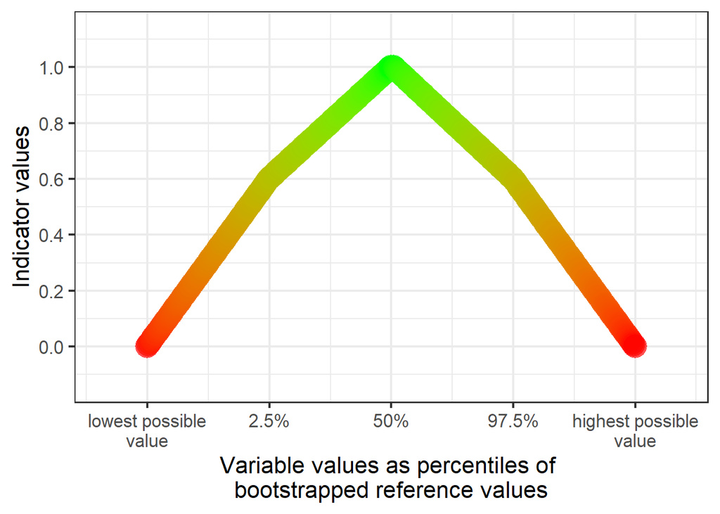

Figure 1: A figure illustrating the normalisation process.The placement of the x60 values are arbitrary in this figure and does not give a representative picture of the relationship between the variable and indicator values.

#### Calculating national and regional indices

We can calculate national and region-wise indicator values using a mixed-effects, zero-one inflated beta-regression analysis. Since the indicator values are on a scale from 0-1 the data per definition dont follow a Gaussian distribution, hence the zero-one inflated beta-regression. Since the underlying monitoring data are spatially aggregated (several points per site), not all points are independent, hence the mixed-effects model.

The uncertainty around the national and region indicator values is derived from the same statistical model.

The national and regional estimates are computed separately.

```r
## Fit ordered beta regression null-model with a random effect
# Norway

Grazing_mowing_no <- glmmTMB(
  Grazing_mowing ~ 1 + (1|nest_1),
  data = combined_lowlands,
  family = ordbeta
)

Grazing_mowing1_no <- glmmTMB(
  Grazing_mowing1 ~ 1 + (1|nest_1),
  data = combined_lowlands |> filter(!is.na(Grazing_mowing1)),
  family = ordbeta
)

Grazing_mowing2_no <- glmmTMB(
  Grazing_mowing2 ~ 1 + (1|nest_1),
  data = combined_lowlands |> filter(!is.na(Grazing_mowing2)),
  family = ordbeta
)

summary(Grazing_mowing_no)
```

```
 Family: ordbeta  ( logit )
Formula:          Grazing_mowing ~ 1 + (1 | nest_1)
Data: combined_lowlands

      AIC       BIC    logLik -2*log(L)  df.resid
   -505.7    -482.7     257.8    -515.7       735

Random effects:

Conditional model:
 Groups Name        Variance Std.Dev.
 nest_1 (Intercept) 0.1106   0.3325
Number of obs: 740, groups:  nest_1, 179

Dispersion parameter for ordbeta family (): 7.09

Conditional model:
            Estimate Std. Error z value Pr(>|z|)
(Intercept)  0.59559    0.04053    14.7   <2e-16 ***
---
Signif. codes:  0 '***' 0.001 '**' 0.01 '*' 0.05 '.' 0.1 ' ' 1
```

```r
summary(Grazing_mowing1_no)
```

```
 Family: ordbeta  ( logit )
Formula:          Grazing_mowing1 ~ 1 + (1 | nest_1)
Data: filter(combined_lowlands, !is.na(Grazing_mowing1))

      AIC       BIC    logLik -2*log(L)  df.resid
   -170.6    -152.4      90.3    -180.6       275

Random effects:

Conditional model:
 Groups Name        Variance Std.Dev.
 nest_1 (Intercept) 0.08067  0.284
Number of obs: 280, groups:  nest_1, 106

Dispersion parameter for ordbeta family (): 6.16

Conditional model:
            Estimate Std. Error z value Pr(>|z|)
(Intercept)  0.64948    0.05833   11.13   <2e-16 ***
---
Signif. codes:  0 '***' 0.001 '**' 0.01 '*' 0.05 '.' 0.1 ' ' 1
```

```r
summary(Grazing_mowing2_no)
```

```
 Family: ordbeta  ( logit )
Formula:          Grazing_mowing2 ~ 1 + (1 | nest_1)
Data: filter(combined_lowlands, !is.na(Grazing_mowing2))

      AIC       BIC    logLik -2*log(L)  df.resid
   -337.5    -316.8     173.7    -347.5       455

Random effects:

Conditional model:
 Groups Name        Variance Std.Dev.
 nest_1 (Intercept) 0.1763   0.4199
Number of obs: 460, groups:  nest_1, 150

Dispersion parameter for ordbeta family (): 8.58

Conditional model:
            Estimate Std. Error z value Pr(>|z|)
(Intercept)  0.61237    0.05191    11.8   <2e-16 ***
---
Signif. codes:  0 '***' 0.001 '**' 0.01 '*' 0.05 '.' 0.1 ' ' 1
```

```r
# regions
Grazing_mowing_re <- glmmTMB(
  Grazing_mowing ~ 0 + region + (1|nest_1),
  data = combined_lowlands,
  family = ordbeta
)

Grazing_mowing1_re <- glmmTMB(
  Grazing_mowing1 ~ 0 + region + (1|nest_1),
  data = combined_lowlands[!is.na(combined_lowlands$Grazing_mowing1),],
  family = ordbeta
)

Grazing_mowing2_re <- glmmTMB(
  Grazing_mowing2 ~ 0 + region + (1|nest_1),
  data = combined_lowlands[!is.na(combined_lowlands$Grazing_mowing2),],
  family = ordbeta
)

summary(Grazing_mowing_re)
```

```
 Family: ordbeta  ( logit )
Formula:          Grazing_mowing ~ 0 + region + (1 | nest_1)
Data: combined_lowlands

      AIC       BIC    logLik -2*log(L)  df.resid
   -502.0    -460.6     260.0    -520.0       731

Random effects:

Conditional model:
 Groups Name        Variance Std.Dev.
 nest_1 (Intercept) 0.1096   0.3311
Number of obs: 740, groups:  nest_1, 179

Dispersion parameter for ordbeta family (): 7.13

Conditional model:
                      Estimate Std. Error z value Pr(>|z|)
regionCentral_Norway   0.44525    0.12354   3.604 0.000313 ***
regionEastern_Norway   0.58281    0.05444  10.705  < 2e-16 ***
regionNorthern_Norway  0.74864    0.09660   7.750 9.21e-15 ***
regionSouthern_Norway  0.48400    0.23331   2.074 0.038035 *
regionWestern_Norway   0.59198    0.10785   5.489 4.04e-08 ***
---
Signif. codes:  0 '***' 0.001 '**' 0.01 '*' 0.05 '.' 0.1 ' ' 1
```

```r
summary(Grazing_mowing1_re)
```

```
 Family: ordbeta  ( logit )
Formula:          Grazing_mowing1 ~ 0 + region + (1 | nest_1)
Data: combined_lowlands[!is.na(combined_lowlands$Grazing_mowing1),      ]

      AIC       BIC    logLik -2*log(L)  df.resid
   -165.3    -132.6      91.6    -183.3       271

Random effects:

Conditional model:
 Groups Name        Variance Std.Dev.
 nest_1 (Intercept) 0.08473  0.2911
Number of obs: 280, groups:  nest_1, 106

Dispersion parameter for ordbeta family (): 6.25

Conditional model:
                      Estimate Std. Error z value Pr(>|z|)
regionCentral_Norway   0.52785    0.14717   3.587 0.000335 ***
regionEastern_Norway   0.73107    0.08373   8.731  < 2e-16 ***
regionNorthern_Norway  0.54628    0.13310   4.104 4.05e-05 ***
regionSouthern_Norway  0.40381    0.40867   0.988 0.323103
regionWestern_Norway   0.66913    0.17353   3.856 0.000115 ***
---
Signif. codes:  0 '***' 0.001 '**' 0.01 '*' 0.05 '.' 0.1 ' ' 1
```

```r
summary(Grazing_mowing2_re)
```

```
 Family: ordbeta  ( logit )
Formula:          Grazing_mowing2 ~ 0 + region + (1 | nest_1)
Data: combined_lowlands[!is.na(combined_lowlands$Grazing_mowing2),      ]

      AIC       BIC    logLik -2*log(L)  df.resid
   -338.4    -301.3     178.2    -356.4       451

Random effects:

Conditional model:
 Groups Name        Variance Std.Dev.
 nest_1 (Intercept) 0.1556   0.3944
Number of obs: 460, groups:  nest_1, 150

Dispersion parameter for ordbeta family (): 8.58

Conditional model:
                      Estimate Std. Error z value Pr(>|z|)
regionCentral_Norway   0.31698    0.19732   1.606   0.1082
regionEastern_Norway   0.55350    0.06508   8.504  < 2e-16 ***
regionNorthern_Norway  0.90869    0.12309   7.382 1.56e-13 ***
regionSouthern_Norway  0.50030    0.27980   1.788   0.0738 .
regionWestern_Norway   0.63748    0.12643   5.042 4.61e-07 ***
---
Signif. codes:  0 '***' 0.001 '**' 0.01 '*' 0.05 '.' 0.1 ' ' 1
```

## 10. Results

The model estimates and standard errors are on a logit scale, but we can calculate indicator values and confidence intervals (CI) by transforming back from logit to values between 0-1

```r
NO_FUBS_001_table <- tibble(
  Region = c(
    "Norway",
    "Central Norway",
    "Eastern Norway",
    "Northern Norway",
    "Southern Norway",
    "Western Norway"
  ),
  indicator_value = c(
    plogis(summary(Grazing_mowing_no)$coef$cond[, 1]),
    plogis(summary(Grazing_mowing_re)$coef$cond[, 1])
  ),
  CI_upper = c(
    plogis(
      summary(Grazing_mowing_no)$coef$cond[, 1] +
        1.96 * summary(Grazing_mowing_no)$coef$cond[, 2]
    ),
    plogis(
      summary(Grazing_mowing_re)$coef$cond[, 1] +
        1.96 * summary(Grazing_mowing_re)$coef$cond[, 2]
    )
  ),
  CI_lower = c(
    plogis(
      summary(Grazing_mowing_no)$coef$cond[, 1] -
        1.96 * summary(Grazing_mowing_no)$coef$cond[, 2]
    ),
    plogis(
      summary(Grazing_mowing_re)$coef$cond[, 1] -
        1.96 * summary(Grazing_mowing_re)$coef$cond[, 2]
    )
  ),
  upper_indicator_value = c(
    plogis(summary(Grazing_mowing2_no)$coef$cond[, 1]),
    plogis(summary(Grazing_mowing2_re)$coef$cond[, 1])
  ),
  n_upper_indicator_value = c(
    summary(Grazing_mowing2_no)$nobs,
    as.vector(table(Grazing_mowing2_re$frame$region))
  ),
  lower_indicator_value = c(
    plogis(summary(Grazing_mowing1_no)$coef$cond[, 1]),
    plogis(summary(Grazing_mowing1_re)$coef$cond[, 1])
  ),
  n_lower_indicator_value = c(
    summary(Grazing_mowing1_no)$nobs,
    as.vector(table(Grazing_mowing1_re$frame$region))
  )
)
NO_FUBS_001_table
```

```
# A tibble: 6 × 8
  Region          indicator_value CI_upper CI_lower upper_indicator_value
  <chr>                     <dbl>    <dbl>    <dbl>                 <dbl>
1 Norway                    0.645    0.663    0.626                 0.648
2 Central Norway            0.610    0.665    0.551                 0.579
3 Eastern Norway            0.642    0.666    0.617                 0.635
4 Northern Norway           0.679    0.719    0.636                 0.713
5 Southern Norway           0.619    0.719    0.507                 0.623
6 Western Norway            0.644    0.691    0.594                 0.654
# ℹ 3 more variables: n_upper_indicator_value <int>,
#   lower_indicator_value <dbl>, n_lower_indicator_value <int>
```

```r
#write.table(
#    NO_FUBS_001_table,
#    file = paste0(here(), "/results/NO_FUBS_001_table.txt"),
#    sep = "\t",
#    row.names = FALSE,
#    quote = FALSE)
```

This analysis is based on data from two different monitoring programs. Here we show the results disaggregated by ANO and ASO.

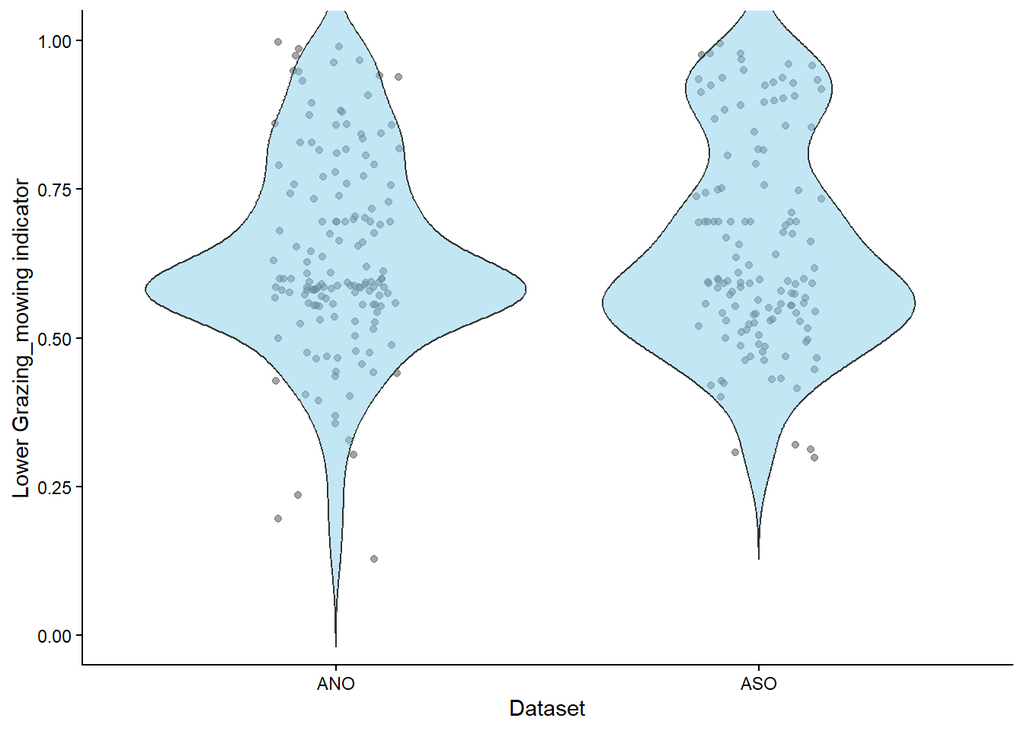

```r
ggplot(combined_lowlands, aes(x = factor(dataset), y = Grazing_mowing1)) +
  geom_jitter(
    width = 0.15, height = 0,
    alpha = 0.5, size = 1.5,
    colour = "grey30"
  ) +
  geom_violin(
    fill = "skyblue",
    alpha = 0.5,
    trim = FALSE
  ) +
  coord_cartesian(ylim = c(0, 1)) +
  labs(x = "Dataset", y = "Lower Grazing_mowing indicator") +
  theme_classic()
```

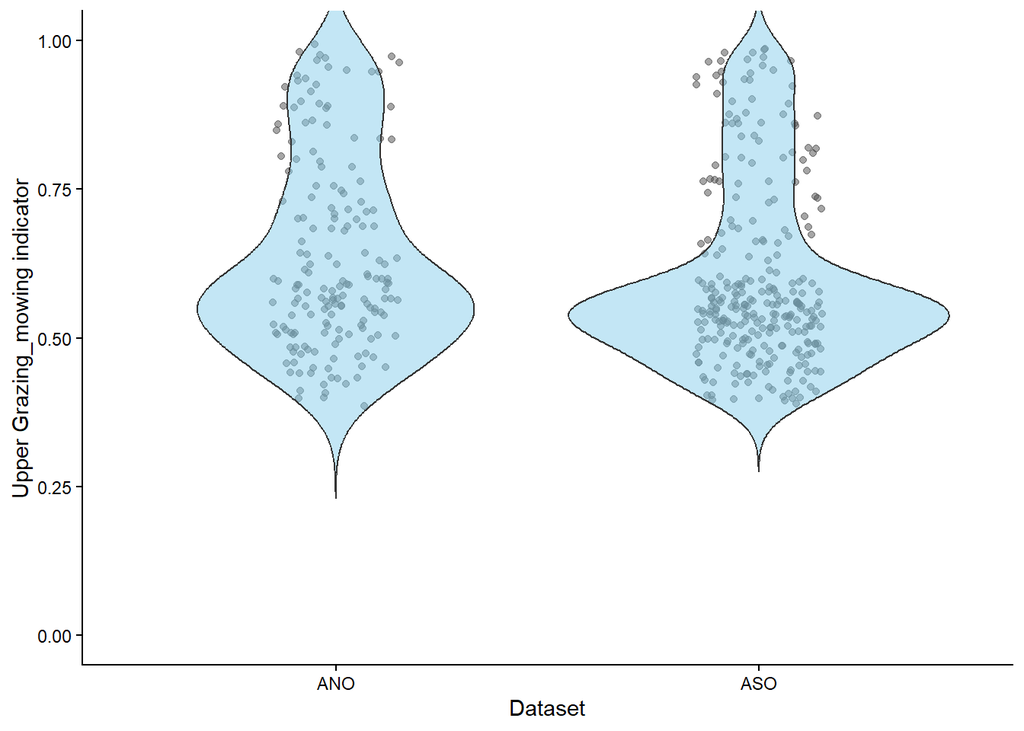

```r
ggplot(combined_lowlands, aes(x = factor(dataset), y = Grazing_mowing2)) +
  geom_jitter(
    width = 0.15, height = 0,
    alpha = 0.5, size = 1.5,
    colour = "grey30"
  ) +
  geom_violin(
    fill = "skyblue",
    alpha = 0.5,
    trim = FALSE
  ) +
  coord_cartesian(ylim = c(0, 1)) +
  labs(x = "Dataset", y = "Upper Grazing_mowing indicator") +
  theme_classic()
```

To express the results as a distribution, we need to simulate mean estimates based on the models intercept and associated standard error.

```r
## Norway
# Fixed-effect intercept and SE
b0 <- fixef(Grazing_mowing_no)$cond["(Intercept)"]
se_b0 <- sqrt(vcov(Grazing_mowing_no)$cond["(Intercept)", "(Intercept)"])
# Dispersion parameter (For glmmTMB this is usually on the response/positive scale via sigma() )
phi <- sigma(Grazing_mowing_no)


# draw estimates and backtransform from logit-scale
eta_draws <- rnorm(1000, mean = b0, sd = se_b0)
mu_draws  <- plogis(eta_draws)


## regions
b_re <- fixef(Grazing_mowing_re)$cond
vc_re <- vcov(Grazing_mowing_re)$cond
phi <- sigma(Grazing_mowing_re)

eta_draws_reg <- MASS::mvrnorm(
  n = 1000,
  mu = b_re,
  Sigma = vc_re
)

mu_draws_reg <- plogis(eta_draws_reg)


# combining Moisture_no_sim and Moisture_re_sim
mu <- mu_draws_reg |>
  as_tibble() |>
  add_column(Norway = mu_draws) |>
  pivot_longer(everything(), names_to = "part") |>
  mutate(part = case_when(
    part == "regionCentral_Norway" ~ "C",
    part == "regionEastern_Norway" ~ "E",
    part == "regionNorthern_Norway" ~ "N",
    part == "regionWestern_Norway" ~ "W",
    part == "regionSouthern_Norway" ~ "S",
    .default = part
  )) #|>
  #add_column(year = "2024")
```

```r
mu |>
  group_by(part) |>
  summarise(
    indicator = mean(value),
    low = round(quantile(value, probs = 0.025), 2),
    high = round(quantile(value, probs = .975), 2)
  ) |>
  unite(col = "95% CI", c(low, high), sep = " - ") |>
  gt::gt() |>
  write.table(
    file = paste0(here(), "/results/NO_FUBS_001_boot_table.txt"),
    sep = "\t",
    row.names = FALSE,
    quote = FALSE)
```

## 11. Export file

```r
arrow::write_parquet(mu,"data/results_NO_FUBS_001.parquet")
```

Demonstrating how to read back the data:

```r
arrow::read_parquet(here::here("data/results_NO_FUBS_001.parquet"))
```

## 12. Author contributions

**CRediT statement**

- Conceptualization: [JT]
- Methodology: [JT,FJ]
- Data curation: [FJ]
- Formal analysis: [FJ,JT]
- Investigation: [FJ,JT]

**MeRIT attribution**

This part supplements the CRediT statement with more granularity for method section.

**Study design** The study was designed by [JT].

**Data processing** Raw data were curated and cleaned by [FJ].

**Statistical analysis** All analyses were conducted by [FJ and JT] , with verification and minor edits by [AH].

**Visualization** Figures were produced by [FJ].

**Reproducibility** All code was reviewed and validated by [AH].

**TipSession Info**

This workflow uses renv. Run `renv::restore()` to get started.